# The Influence of Terrorist Attacks on the Agendas of Eurosceptic Right-Wing Parties

*Rassemblement National as Case Study*

Author

Martina Chizzola

# Introduction

**Research Question**: To what extent did Terrorist Attacks Affected the Agenda of *Rassemblement National*?

Since the beginning of the millennium, the world has seen the emergence and development of occurrences that have altered the way in which people perceive their surroundings. Among such events, a critical one has been the finalization of terrorist attacks across the globe for political and religious reasons, such as the offensives carried out in the United States on 9/11, or the events in France in 2015 or in Spain in 2016. In particular, Europe has been In particular, Europe has been the target of such aggressions in the late 2010s, with 17 attacks in 2015, 33 in 2017, and 24 in 2018 (European Council), which were executed in cities such as Paris, Nice, Barcelona, and Berlin. As a consequence, both European citizens and political parties have started to hold the European Union accountable for the happenings, stating that they could have been prevented if measures had been correctly implemented.

The aim of this report is to analyze how terrorist attacks have influenced the manifesto and *Rassemblement National*, a Eurosceptic political party of a countries where offensives have been carried out. To better quantify the extent of the impact, I will take into consideration political speeches of the French Parliament between 2010 and 2021, and perform LDA (*Latent Dirichlet Allocation*) to show which words the exponents of the party have used the most in the time frame.

# Context

## *Global Impact of Terrorism*

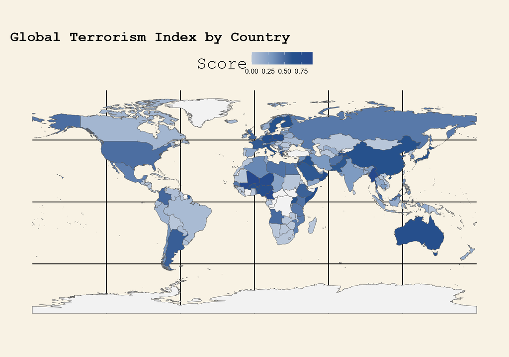

## *Arrivals Per Country in 2015 and 2017*

[figure not shown]

|

[figure not shown]

The high number of arrivals, combined with the execution of a series of terrorist attacks, which could be traced back to the Islamic State, within the border of the Union, fueled the sentiment of Euroscepticism, namely the sentiment of distrust towards the European Union and its policies. Despite of the sentiment being present since the early origins of the institution, during this period it became notable in political discourses once again.

# *Rassemblement National*

## *The Party*

[figure not shown]

*Rassemblement National* (RN) is the main Right-wing French political party, and during the latest decades, it has adopted Eurosceptic views, with principles opposing fundamental EU values, such as the freedomon of movement and the Schengen Agreement. Moreover, members of this party call for more national Sovereignty, which is thought to be undermined by the presence of an supranational institution, seen as a threat for national jurisdiction and democracy. As a matter of fact, according to Marine Le Pen, ex-Party leader, France should have its legislative economic, territorial, and monetary sovereignty restored.

## *Paris 2015*

On the night of the 13th November 2015, Terrorists spread in various parts of the Capital carried out an offensive, which led to the death of 138 people, including 8 attackers, and 350 injuries. The main targets were places where people gathered, such as the *Stade de France*, where a football game was being played with the President in the grandstand, and the *Bataclan Concert Hall*, which later became the symbol of the attack, eventually claimed by ISIS.

Here you can find a video shoot right in front of the theater soon after the beginning of the attack (**DISCLAIMER**: the video may contain frames that may be found disturbing) [Watch on YouTube](https://www.youtube.com/watch?v=v7pr2o9KoE8)

# Text Analysis

## *Parliamentary Speeches*

The method selected to conduct the analysis was LDA (*Latent Dirichlet Allocation*), in order to extract relevant words and themes from the texts in the dataframe.

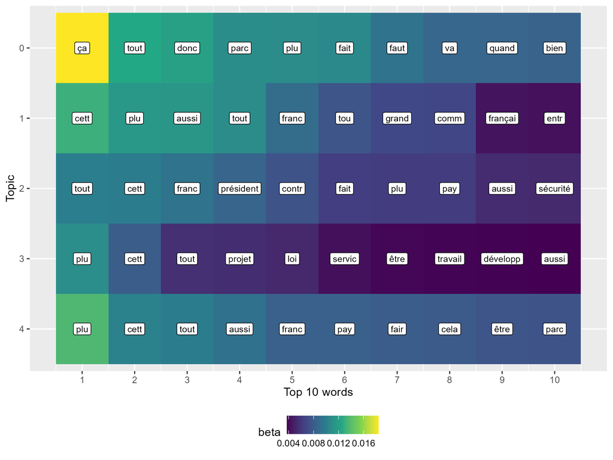

## *Time Trend*

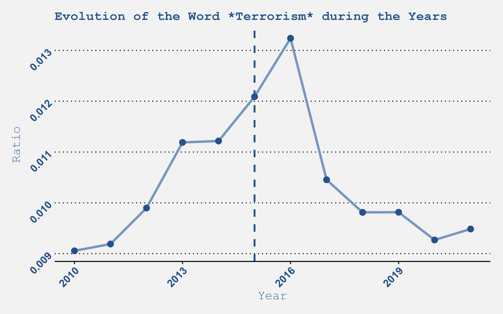

# Conclusions

## *Policy Implications*

After the attack, leaders of the *Rassemblement National* have strenghtened their political position and their nationalist ideas, advocating for a reform of European policies, in particular of the freedom of movement policy and of the Schengern Agreement. As a matter of fact, these practices allow for the free movement of goods and of people among European member-States, *de facto* abolishing border controls. Moreover, some mayors in small towns affiliated with *Rassemblement National* have enacted local laws, such as the banning of female swimwear that cover the whole body, and have delayed the constructions of Mosques.

# Appendix

Should you be interesed in how I conducted the analysis, below you can find a breakdown of the R and Pyhton codes I have used

## *Global Impact of Terrorism*

```r
# Loading Relevant Packages
library(dplyr)
library(ggplot2)
library(sf)
library(rnaturalearth)
library(rnaturalearthdata)
library(readxl)
library(ggthemes)

# Setting the Path
impact_terrorism <- read_excel("C:/Users/marti/Desktop/Text_analysis/project/global terrorism index.xlsx")
```

```r
# Load the map
world <- ne_countries(scale = "medium", returnclass = "sf")

# Perform a Left Join
map_data <- world %>%
  left_join(impact_terrorism, by = c("name" = "region"))
```

```r
# Plotting the Data Using Ggplot
ggplot(data = map_data) +
  geom_sf(aes(fill = score)) +
  scale_fill_gradientn(
    colours = c("#B8C6D9", "#7897BF", "#26528C", "#26488C"),
    na.value = "#F2F2F2"
  ) +
  theme_wsj() +  # Applying the WSJ theme
  theme(
    plot.title = element_text(size = 20),
    panel.grid = element_blank()
  ) +
  labs(
    title = "Global Terrorism Index by Country",
    fill = "Score"
  )
```

## *Arrivals Graphs*

```r
# Cleaning the Data removing N/As
fifteen_flow_cleaned<-subset(na.omit(fifteen_flow))
```

```r
# Creating the Graph Using GGplot
library(ggthemes)
fifteen_flow_cleaned_graph <- ggplot(data = fifteen_flow_cleaned, aes(x = Country, y = Total)) +
  geom_col(aes(fill = Country)) +
  scale_fill_manual(values = c(
  "Bulgaria" = "#26488C",
  "Cyprus" = "#26528C",
  "Greece" = "#7897BF",
  "Italy" = "#B8C6D9" ,
  "Spain" = "#AEBFD3",
  "Malta" = "#C0CDDC",
  "Total" = "#D0D8E8"
)) +
  theme_wsj() +
  guides(fill = "none") +
 theme(
    panel.background = element_rect(fill = "#F2F2F2", color = NA),
    plot.background = element_rect(fill = "#F2F2F2", color = NA),
    axis.text.x = element_text(angle = 45, hjust = 1)
  )

fifteen_flow_cleaned_graph
```

## *Rassemblament National*-*LDA*

```python
#Import Relevant Library (JSON was used to import a JSON file)
import pandas as pd
import json
# import spacy
# from sklearn.feature_extraction.text import CountVectorizer
# from sklearn.decomposition import LatentDirichletAllocation
# import matplotlib.pyplot as plt
# from wordcloud import WordCloud
# nlp = spacy.load("fr_core_news_sm") (this specific library was used to import French Stopwords)
import pandas as pd
from sklearn.feature_extraction.text import CountVectorizer
from gensim.models.ldamodel import LdaModel
from gensim import corpora
from nltk.corpus import stopwords
from nltk.stem.porter import PorterStemmer
import numpy as np
```

```python
from unidecode import unidecode
# Load French stopwords
stop_words = set(stopwords.words("french"))

# Add non-accented stopwords to the existing ones
stop_words_non_accented = set(stopwords.words("french"))  # Copy the original stopwords
stop_words_non_accented = stop_words_non_accented.union({unidecode(word) for word in stop_words})

# Here is the final set with both accented and non-accented stopwords
combined_stopwords = stop_words.union(stop_words_non_accented)
combined_stopwords
```

```python
# Preprocess the text
def preprocess(text):
    stemmer = PorterStemmer()
    #stop_words = set(stopwords.words("french"))
    tokens = text.lower().split()  # Simple tokenization
    tokens = [word for word in tokens if word.isalnum()]  # Remove punctuation
    tokens = [word for word in tokens if word not in combined_stopwords]  # Remove stopwords
    tokens = [stemmer.stem(word) for word in tokens]  # Stem words
    return tokens
# Drop N/A Values
df2 = df[df["text"].notna()]
```

```python
# Selecting a Random Sample of 5000 texts
df3 = df2.sample(n=5000, random_state=123)

# Tokenize the texts
df3["tokens"] = df3["text"].progress_apply(preprocess)

#Pre-Processing the Texts
df3["speech_id"] = range(1, len(df3) + 1)
```

```python
# Create a dictionary and corpus for LDA
from gensim.corpora.dictionary import Dictionary

dictionary = Dictionary(df3["tokens"])
corpus = [dictionary.doc2bow(text) for text in df3["tokens"]]

#Train LDA Model
import gensim
lda_model = gensim.models.LdaModel(corpus=corpus, id2word=dictionary, num_topics=5, passes=10, random_state=42)

# Loop through each topic
for topic_id in range(lda_model.num_topics):
    top_terms += [(topic_id, term, prob) for term, prob in lda_model.show_topic(topic_id, topn=10)]

# Convert top terms to a DataFrame
top_terms_df = pd.DataFrame(top_terms, columns=["topic", "term", "beta"])
```

```python
# Rank beta within each topic group in a descending order
top_terms_df['rank'] = top_terms_df.groupby('topic')['beta'] \
                             .rank(method='min', ascending=False)

# Filter for topics (the most relevant ones)
result_df = top_terms_df[top_terms_df['topic'] <= 10]
```

```r
# Loading libraries in R to plot the graph
library(dplyr)
library(broom)
library(ggplot2)
#Turning the Pandas dataframe to R
result_df <- reticulate::py$result_df

#Creating a graph with the topics
topics_lda_keys<-ggplot(result_df, aes(y = reorder(topic, -topic), x = as.numeric(rank))) +
  geom_tile(aes(fill = beta))+
  scale_fill_viridis_c()+
  geom_label(aes(y=reorder(topic, -topic), x=rank, label=term), fill="white", size=3)+
  scale_x_continuous(breaks = seq(min(result_df$rank), max(result_df$rank))) +  # Ensure all ranks are shown
  ylab("Topic")+ xlab("Top 10 words")+
  theme(legend.position = "bottom")
topics_lda_keys
```

## *Rassemblament National*- *Creation of a Time Trend*

```python
# Selection of Keywords Associated with Terrorism and Security
keywords_fr = [
    # Sécurité et réponse
    "sécurité", "protection", "défense", "renseignement", "territoire",
    "surveillance", "armée", "soldats", "frappes aériennes", "déploiement",
    "intervention", "urgence", "préparation", "forces de l'ordre", "antiterrorisme",

    # Terrorisme et menace
    "terrorisme", "terroristes", "extrémisme", "radical", "radicalisé",
    "militant", "attaque", "attentat", "bombe", "violence", "menace",
    "complot", "massacre", "djihad", "État islamique", "Al-Qaïda",

    # Unité et valeurs
    "liberté", "démocratie", "justice", "patriotisme", "détermination",
    "unité", "valeurs françaises", "mode de vie", "résilience", "solidarité",

    # Émotion et peur
    "peur", "horreur", "tragédie", "deuil", "chagrin", "désastre",
    "inquiétude", "panique", "colère", "condamner", "sécurité des citoyens",

    # Politique et lois
    "loi", "projet de loi", "législation", "réforme", "décret",
    "immigration", "frontière", "visa", "asile", "réfugié", "interdiction"
]
```

```python
# Tokenizing the texts in the DataFrame
df3["tokens"]

# Lowercasing the text column
df3["text2"] = df3["text"].str.lower()

# Counting keyword occurrences per text
def count_keywords(text, keywords):
    return sum(text.count(keyword.lower()) for keyword in keywords)

df3["keyword_count"] = df3["text"].apply(lambda x: count_keywords(x, keywords_fr))
# Count total number of words per text
df3["word_count"] = df3["text"].str.split().apply(len)
df3["terrorism_ratio"] = df3["keyword_count"]/df3["word_count"]
```

```python
# Extracting the year
df3["year"] = df3["datetime"].dt.year

# Grouping by year and aggregating keyword and word counts
yearly_stats = df3.groupby("year")[["keyword_count", "word_count"]].sum().reset_index()

# Computing terrorism ratio per year
yearly_stats["terrorism_ratio"] = yearly_stats["keyword_count"] / yearly_stats["word_count"]
yearly_stats.to_csv("yearly_stats.csv", index=False)
```

```r
# Transforming the Pands DataFrame jn a format readable by R
yearly_stats <- read.csv("yearly_stats.csv")

# Importing Relevant Libraries and Plotting the Graph
library(dplyr)
library(stringr)
library(lubridate)
library(ggplot2)
library(ggthemes)

ggplot(yearly_stats, aes(x = year, y = terrorism_ratio)) +
  geom_line(color = "#7897BF",
            size = 1.3 ) +
  geom_point(color = "#26528C",
            size = 3) +
  labs(
    title = "Evolution of the Word *Terrorism* during the Years",
    x = "Year",
    y = "Ratio"
  ) +
  theme_wsj() +
  guides(fill = "none") +
 theme(
    panel.background = element_rect(fill = "#F2F2F2", color = NA),
    plot.background = element_rect(fill = "#F2F2F2", color = NA),
    axis.text.x = element_text(angle = 45, hjust = 1, color = "#26528C"),
    axis.text.y = element_text(angle= 45, hjust = 1, color = "#26528C"),
    plot.title = element_text(size = 15, face = "bold", color = "#26528C"),
    axis.title.x = element_text(size = 14, color = "#26528C"),
    axis.title.y = element_text(size = 14, color = "#26528C" )
  )+
  geom_vline(xintercept = 2015, linetype = "dashed", color = "#26528C", size = 1)
```